# Practical Machine Learning Project

Matthew Kruse

April 17, 2016

#### Overview

The goal of this analysis is to use data from accelerometers on the belt, forearm, arm, and dumbell of 6 participant and to predict whether barbell lifts were done correctly or incorrectly in 5 different ways. The ‘classe’ variable in the training and test sets contains the result of the lift by the particpants.

#### Gather and Explore Data

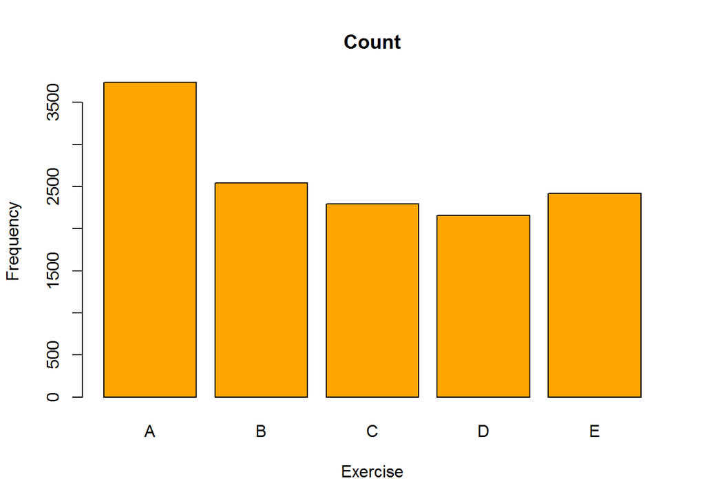

```r
download.file('https://d396qusza40orc.cloudfront.net/predmachlearn/pml-training.csv', 'training.csv')
download.file('https://d396qusza40orc.cloudfront.net/predmachlearn/pml-testing.csv', 'test.csv')
train <- read.csv('training.csv', na.strings=c('NA', '', '#DIV/0!'))

# str(training) showed that we probably don't care about a number of columns so removing them, mainly timestamps, row ids and [new|num]window
remove_cols <- c('X', 'user_name', 'raw_timestamp_part_1', 'raw_timestamp_part_2', 'cvtd_timestamp', 'new_window', 'num_window')
train <- train[ , !(names(train) %in% remove_cols)]

# break up the data into a test/training set
set.seed(1)
library(caret)
train_part <- createDataPartition(y=train$classe,p=0.67,list=F)
training <- train[train_part,]
testing <- train[-train_part,]

validation <- read.csv('test.csv', na.strings=c('NA', '', '#DIV/0!'))
validation <- validation[ , !(names(validation) %in% remove_cols)] # remove the same columns from the validation set

plot(training$classe, col="orange", main="Count", xlab="Exercise", ylab="Frequency")
```

From looking over the raw data, looks like many of the variables are very sparse. Remove anything where the training set has more then 10K NA’s

```r
keep <- c()
remove <- c()
for (name in names(training)) {
  cnt <- sum(is.na(training[,name]))

  if (cnt < 10000) {
    keep <- c(keep, name)
  }
  else {
    remove <- c(remove, name)
  }
}

training <- training[, !(names(training) %in% remove)]
testing <- testing[, !(names(testing) %in% remove)]
validation <- validation[, !(names(validation) %in% remove)]
```

Building four models, lda (Latent Dirichlet Allocation), rpart (decision tree), rf (random forest) and gbm (boosting) Mainly choose boosting and the random forest models as the lectures indicated those typically are the best predictors in prediction contests. The other two are models that the course presented in the lectures. They were also quick to process as compared to the random forest and boosting models.

```r
model1 <- train(classe ~., data=training, method="lda", na.action='na.omit') # Latent Dirichlet Allocation
model2 <- train(classe ~., data=training, method="rpart", na.action='na.omit') # decision tree
model3 <- train(classe ~., data=training, method='rf', na.action='na.omit') # random forest
model4 <- train(classe ~., data=training, method='gbm', na.action='na.omit') # boosting
```

```r
pred1 <- predict(model1, newdata=testing)
confusionMatrix(pred1,testing$classe)
```

```
## Confusion Matrix and Statistics
##
##           Reference
## Prediction    A    B    C    D    E
##          A 1514  200  119   74   52
##          B   35  817  104   49  196
##          C  140  139  759  124   93
##          D  144   41  118  766  115
##          E    8   56   29   48  734
##
## Overall Statistics
##
##                Accuracy : 0.709
##                  95% CI : (0.6978, 0.72)
##     No Information Rate : 0.2844
##     P-Value [Acc > NIR] : < 2.2e-16
##
##                   Kappa : 0.6314
##  Mcnemar's Test P-Value : < 2.2e-16
##
## Statistics by Class:
##
##                      Class: A Class: B Class: C Class: D Class: E
## Sensitivity            0.8224   0.6520   0.6723   0.7220   0.6168
## Specificity            0.9039   0.9265   0.9072   0.9228   0.9733
## Pos Pred Value         0.7728   0.6803   0.6048   0.6470   0.8389
## Neg Pred Value         0.9276   0.9173   0.9291   0.9442   0.9186
## Prevalence             0.2844   0.1935   0.1744   0.1639   0.1838
## Detection Rate         0.2339   0.1262   0.1172   0.1183   0.1134
## Detection Prevalence   0.3026   0.1855   0.1939   0.1829   0.1352
## Balanced Accuracy      0.8632   0.7892   0.7897   0.8224   0.7951
```

```r
pred2 <- predict(model2, newdata=testing)
confusionMatrix(pred2,testing$classe)
```

```
## Confusion Matrix and Statistics
##
##           Reference
## Prediction    A    B    C    D    E
##          A 1651  481  512  494  162
##          B   32  449   35  186  145
##          C  131  323  582  381  314
##          D    0    0    0    0    0
##          E   27    0    0    0  569
##
## Overall Statistics
##
##                Accuracy : 0.5022
##                  95% CI : (0.4899, 0.5144)
##     No Information Rate : 0.2844
##     P-Value [Acc > NIR] : < 2.2e-16
##
##                   Kappa : 0.3502
##  Mcnemar's Test P-Value : NA
##
## Statistics by Class:
##
##                      Class: A Class: B Class: C Class: D Class: E
## Sensitivity            0.8968  0.35834   0.5155   0.0000  0.47815
## Specificity            0.6441  0.92377   0.7850   1.0000  0.99489
## Pos Pred Value         0.5003  0.53011   0.3362      NaN  0.95470
## Neg Pred Value         0.9401  0.85712   0.8847   0.8361  0.89435
## Prevalence             0.2844  0.19354   0.1744   0.1639  0.18381
## Detection Rate         0.2550  0.06935   0.0899   0.0000  0.08789
## Detection Prevalence   0.5097  0.13083   0.2674   0.0000  0.09206
## Balanced Accuracy      0.7704  0.64105   0.6503   0.5000  0.73652
```

```r
pred3 <- predict(model3, newdata=testing)
confusionMatrix(pred3,testing$classe)
```

```
## Confusion Matrix and Statistics
##
##           Reference
## Prediction    A    B    C    D    E
##          A 1840    6    0    0    0
##          B    1 1246    8    0    0
##          C    0    1 1119   17    0
##          D    0    0    2 1043    3
##          E    0    0    0    1 1187
##
## Overall Statistics
##
##                Accuracy : 0.994
##                  95% CI : (0.9918, 0.9957)
##     No Information Rate : 0.2844
##     P-Value [Acc > NIR] : < 2.2e-16
##
##                   Kappa : 0.9924
##  Mcnemar's Test P-Value : NA
##
## Statistics by Class:
##
##                      Class: A Class: B Class: C Class: D Class: E
## Sensitivity            0.9995   0.9944   0.9911   0.9830   0.9975
## Specificity            0.9987   0.9983   0.9966   0.9991   0.9998
## Pos Pred Value         0.9967   0.9928   0.9842   0.9952   0.9992
## Neg Pred Value         0.9998   0.9987   0.9981   0.9967   0.9994
## Prevalence             0.2844   0.1935   0.1744   0.1639   0.1838
## Detection Rate         0.2842   0.1925   0.1728   0.1611   0.1833
## Detection Prevalence   0.2851   0.1939   0.1756   0.1619   0.1835
## Balanced Accuracy      0.9991   0.9963   0.9939   0.9911   0.9986
```

```r
pred4 <- predict(model4, newdata=testing)
confusionMatrix(pred4,testing$classe)
```

```
## Confusion Matrix and Statistics
##
##           Reference
## Prediction    A    B    C    D    E
##          A 1806   42    0    0    1
##          B   26 1176   34    4   16
##          C    4   34 1080   31   11
##          D    3    0   12 1015    9
##          E    2    1    3   11 1153
##
## Overall Statistics
##
##                Accuracy : 0.9623
##                  95% CI : (0.9574, 0.9668)
##     No Information Rate : 0.2844
##     P-Value [Acc > NIR] : < 2.2e-16
##
##                   Kappa : 0.9523
##  Mcnemar's Test P-Value : 9.201e-06
##
## Statistics by Class:
##
##                      Class: A Class: B Class: C Class: D Class: E
## Sensitivity            0.9810   0.9385   0.9566   0.9566   0.9689
## Specificity            0.9907   0.9847   0.9850   0.9956   0.9968
## Pos Pred Value         0.9767   0.9363   0.9310   0.9769   0.9855
## Neg Pred Value         0.9924   0.9852   0.9908   0.9915   0.9930
## Prevalence             0.2844   0.1935   0.1744   0.1639   0.1838
## Detection Rate         0.2790   0.1816   0.1668   0.1568   0.1781
## Detection Prevalence   0.2856   0.1940   0.1792   0.1605   0.1807
## Balanced Accuracy      0.9859   0.9616   0.9708   0.9761   0.9828
```

```r
pred5 <- predict(model3, validation)
validation$classe <- predict(model3, validation)
summary(validation$classe)
```

```
## A B C D E
## 7 8 1 1 3
```

Based off the prediction success rate we would expect 1 or fewer of the predictions from the 20 in the validation set to be incorrect.